# RBI112_Course_Proj_SH

Sammi Huang

2023-09-18

# 1 Introduction:

Cancer is a multifaceted disease characterized by a number of cellular alterations that lead to uncontrolled cell proliferation. Depending on the cancer type, the disease is met with a very poor survival rate and limited treatment options which often have severe side effects and have marginal effects at best. To put this into perspective, individuals have about a 50% chance of developing cancer in their lifetime (PMID: 21772332, PMID: 25647015). Like many types of cancer, I would argue that most diseases do not have a cure and are only managed by the medical field. My point behind mentioning this information is not to be grim minded or negative, it’s to point out that serious biological problems exist in this world that do not have answers. In this field, whether you work in an academic, industry, or teaching setting you will have the opportunity and privilege to participate in the discovery, implementation, or communication, respectively, of information geared towards finding solutions to these problems. In my opinion, there is no better use of my time and I can not think of anything more important to direct my efforts towards. The challenges you face in this class, once you overcome them (which you will with some perseverance) will provide you with a skill set that contributes to solving these issues, even if you feel as though your contributions are marginal, they have a large collective impact. This course project is geared towards implementing the concepts in this course to develop a model for the classification of breast cancer. These types of analyses have a high degree of clinical relevance as precision oncology continues to become more main stream. So, let’s get down to business.

## 1.1 Introduction to TCGA

The Cancer Genome Atlas (TCGA) is a cancer genomics database launched in 2006 containing sequencing profiles annotated with patient meta data for over 20,000 primary cancer samples comprising 33 cancer types matched with normal control samples. Although gene expression profiles housed in this database are of primary concern for this course, TCGA houses multi-Omics data types including whole genome methylation patterns, DNA copy numbers, and microRNA profiles. Numerous landmark discoveries on tumor characteristics, classification, and treatment have eminated from the TCGA database which continues to be an exemplary source of data for researchers to bridge genomic information into clinical applications. Although TCGA is a profound resource, as with everything in life, it is not without its limitations. For example, TCGA contains molecular data curated from bulk tissue samples which is nor resolved at single cell resolution. Since mounting evidence indicates there is extensive cellular heterogeniety within a tumor it is difficult to investigate the level of tumor heterogeneity within the context of the TCGA database. However, within the scope of this course, and within the applications of sequencing technologies in diagnostics and precision medicine, the TCGA database will serve us well.

Although most of the content is directly available through their website here. We will be accessing the data through their application programming interfact (API) which will allow us to select data profiles we are interested in and import them directly into R. Although the resources on the TCGA website are quite extensive, obtaining the raw data provides greater flexibility and freedom to perform custom analyses not available on the website. The following sections illustrate how to download data including the data necessary for your course project.

# 2 TCGA data

load packages:

```r
#BiocManager::install("TCGAbiolinks")
#BiocManager::install("EDASeq")
library(TCGAbiolinks); library(EDASeq)

#information on types of cancer datasets are available through TCGA via getGDCprojects()

projects <- getGDCprojects()
head(projects[,c("id","project_id","released","tumor")])
```

```
##              id    project_id released tumor
## 1 CGCI-HTMCP-CC CGCI-HTMCP-CC     TRUE HTMCP
## 2    TARGET-AML    TARGET-AML     TRUE   AML
## 3     GENIE-JHU     GENIE-JHU     TRUE   JHU
## 4     GENIE-MSK     GENIE-MSK     TRUE   MSK
## 5    GENIE-VICC    GENIE-VICC     TRUE  VICC
## 6     GENIE-MDA     GENIE-MDA     TRUE   MDA
```

```r
#determine the number of RNAseq samples, and specify control samples, that are available for each project:
id <- projects$id
smpls <- list()
for(i in 1:length(id)){
  temp <- NULL
  query_Target <- NULL
  tryCatch({
    query_Target <- GDCquery(project = id[i],
                             data.category = "Transcriptome Profiling",
                             data.type = "Gene Expression Quantification",
                             workflow.type = "STAR - Counts")
  }, error= function(e){cat("ERROR", id[i], ":" ,conditionMessage(e), "\n")})
  if(!is.null(query_Target)){
  samplesDown_Target <- getResults(query_Target)#, cols = c("cases"))
  temp[[1]] <- table(samplesDown_Target$sample_type)
  names(temp) <- id[i]
  } else {
    temp[[1]] <- NA
    names(temp) <- id[i]
  }
  smpls <- c(smpls, temp)
}
```

[output not shown]

[output cut: 36 more lines]

[output not shown]

```r
#check list to narrow down the cancer we would like to work on into four diff projects (CPTAC-3, REB-THYR, TCGA-COAD, TCGA-BRCA)
smpls
```

```
## $`CGCI-HTMCP-CC`
##
## Primary Tumor
##           196
##
## $`TARGET-AML`
##
##      Blood Derived Cancer - Bone Marrow, Post-treatment
##                                                      25
## Blood Derived Cancer - Peripheral Blood, Post-treatment
##                                                       1
##                                    Blood Derived Normal
##                                                      31
##                                      Bone Marrow Normal
##                                                     412
##                                              Cell Lines
##                                                      18
##                            Next Generation Cancer Model
##                                                      50
##              Primary Blood Derived Cancer - Bone Marrow
##                                                    1890
##         Primary Blood Derived Cancer - Peripheral Blood
##                                                     355
##            Recurrent Blood Derived Cancer - Bone Marrow
##                                                     412
##       Recurrent Blood Derived Cancer - Peripheral Blood
##                                                      31
##
## $`GENIE-JHU`
## [1] NA
##
## $`GENIE-MSK`
## [1] NA
##
## $`GENIE-VICC`
## [1] NA
##
## $`GENIE-MDA`
## [1] NA
##
```

[output cut: 434 more lines]

```
##
## $`REBC-THYR`
##
##       Primary Tumor Solid Tissue Normal
##                 428                 400
##
## $`TCGA-KIRP`
##
## Additional - New Primary            Primary Tumor      Solid Tissue Normal
##                        1                      290                       32
##
## $`TCGA-THYM`
##
##       Primary Tumor Solid Tissue Normal
##                 120                   2
```

```r
posIDs <- c("CPTAC-3", "REBC-THYR", "TCGA-COAD", "TCGA-BRCA")
projects[projects$id %in% posIDs, ]
```

```
##           id primary_site dbgap_accession_number project_id disease_type
## 30 TCGA-BRCA       Breast                   <NA>  TCGA-BRCA Squamous....
## 31   CPTAC-3 Bronchus....              phs001287    CPTAC-3 Squamous....
## 32 TCGA-COAD Colon, R....                   <NA>  TCGA-COAD Adenomas....
## 80 REBC-THYR Thyroid ....                   <NA>  REBC-THYR Adenomas....
##                                                                                                   name
## 30                                                                           Breast Invasive Carcinoma
## 31                                          CPTAC-Brain, Head and Neck, Kidney, Lung, Pancreas, Uterus
## 32                                                                                Colon Adenocarcinoma
## 80 Comprehensive genomic characterization of radiation-related papillary thyroid cancer in the Ukraine
##    releasable state released tumor
## 30       TRUE  open     TRUE  BRCA
## 31       TRUE  open     TRUE     3
## 32       TRUE  open     TRUE  COAD
## 80       TRUE  open     TRUE  THYR
```

```r
#Based on bases, breast cancer carcinoma has the greatest number of samples, focus on breast cancer in this course project:
smpls[names(smpls) %in% posIDs[3:4]]
```

```
## $`TCGA-BRCA`
##
##          Metastatic       Primary Tumor Solid Tissue Normal
##                   7                1111                 113
##
## $`TCGA-COAD`
##
##          Metastatic       Primary Tumor     Recurrent Tumor Solid Tissue Normal
##                   1                 481                   1                  41
```

# 3 Data Download

```r
#gets summary and information about genomics data specific for project -- we will be looking at "transcriptome profiling" datasets
TCGAbiolinks:::getProjectSummary("TCGA-BRCA")
```

```
## $file_count
## [1] 58776
##
## $data_categories
##   file_count case_count               data_category
## 1       7562       1098            Sequencing Reads
## 2       5316       1098                 Biospecimen
## 3      12066       1098       Copy Number Variation
## 4      17111       1098 Simple Nucleotide Variation
## 5       4876       1097     Transcriptome Profiling
## 6       3714       1097             DNA Methylation
## 7       2288       1098                    Clinical
## 8       4924       1095        Structural Variation
## 9        919        881          Proteome Profiling
##
## $case_count
## [1] 1098
##
## $file_size
## [1] 1.813754e+14
```

In this next set of code, we specify that we are interested in “Transcriptome Profiling” data from the “TCGA-BRCA” database in the`GDCquery()` function. This information returned from this function is passed onto the `getResults()` function that returns the file names and ids that can be downloaded.

```r
#interested in "Transcriptome Profiling" from "TCGA BRCA" database in GDCquery() function.

#### Downloading and prepare TARGET CASE ####
TargetSamples <- GDCquery(project = "TCGA-BRCA",
                         data.category = "Transcriptome Profiling",
                         data.type = "Gene Expression Quantification",
                         workflow.type = "STAR - Counts")
#### obtain case information ####
CaseInfo <- getResults(TargetSamples)#, cols = c("cases"))
head(CaseInfo)
```

```
##                                     id data_format                        cases
## 1 a5c799bc-1332-4127-8fda-84da04084d25         TSV TCGA-A7-A26E-01B-06R-A277-07
## 2 1dd898ab-3b85-4932-b889-0eb0a494f2b6         TSV TCGA-A2-A0CU-01A-12R-A034-07
## 3 7286a685-17ef-4ef5-9b7b-2696c6e7e1a6         TSV TCGA-PL-A8LV-01A-21R-A41B-07
## 4 de6f1503-33d7-4f86-b835-bdffba7ea4e3         TSV TCGA-BH-A0BC-01A-22R-A084-07
## 5 4c46a463-f0e3-4e19-ad95-5dab0231d1c6         TSV TCGA-AR-A1AX-01A-11R-A12P-07
## 6 586d9c21-e58a-4171-9755-30c0e8b16293         TSV TCGA-AC-A2FO-01A-11R-A180-07
##   access
## 1   open
## 2   open
## 3   open
## 4   open
## 5   open
## 6   open
##                                                                     file_name
```

[output cut: 69 more lines]

Instead of downloading the entire data set, we can subset the which records we would like to download. In the example illustrated below, 113 cancer and control data sets are downloaded. Although model building performance is typically better with more data, there might be limitations to the amount of data a computer can handle based on the available RAM. If the entire 226 samples cannot be loaded in your computer, you will need to download fewer samples until the daya can be loaded.

```r
#### subset samples so that there is an equal number of cancer and control samples ####
dataPrimary_Target <- TCGAquery_SampleTypes(barcode = CaseInfo$cases, typesample = "TP") # primary tumor
dataNormal_Target <- TCGAquery_SampleTypes(barcode = CaseInfo$cases, typesample = "NT") # normal tissue
dataPrimary_Target <- dataPrimary_Target[1:113]
dataNormal_Target <- dataNormal_Target[1:113]
#### downloaded samples of interest ####
TargetSamples <- GDCquery(project = "TCGA-BRCA",
                             data.category = "Transcriptome Profiling",
                             data.type = "Gene Expression Quantification",
                             workflow.type = "STAR - Counts",
                             barcode = c(dataPrimary_Target, dataNormal_Target))
#### Download the data (Note: Depending on your computer, you may not have enough RAM to process this amount of data. If this happens, please subset the data
#### to include 50 cancer and 50 normal tissue samples)
GDCdownload(TargetSamples, dir = "C:\\Users\\sammi\\Desktop\\Brandeis\\RBIF112 Mathematical modeling\\Course_project") # will download 226 files and about 960 MB of data
```

## 3.1 Data Preparation

The `TCGAbiolinks` package contains pre-scripted functions that handle the downloaded data and format it into a `summarizedExperiment` object, here called `data` that contains all of the meta data as well as meta data that is associated with the raw data set. As we can see there is a wealth of information for both the column meta data accessed with `thecolData()` function as well as the row meta data accessed with the `rowData()` function. After looking a These data sets, we can ask several questions such as: Can we predict what stage the tumor is in? Can we predict if a tissue sample is from a tumor or normal tissue? Is there an ethnicity component to the gene expression profiles? Can we predict days to death or vital status?

```r
data <- GDCprepare(TargetSamples, dir ="C:\\Users\\sammi\\Desktop\\Brandeis\\RBIF112 Mathematical modeling\\Course_project" )
```

[output not shown]

[output cut: 172 more lines]

[output not shown]

```r
assays(data)
```

```
## List of length 6
## names(6): unstranded stranded_first ... fpkm_unstrand fpkm_uq_unstrand
```

```r
colData(data)
```

```
## DataFrame with 226 rows and 87 columns
##                                             barcode      patient
##                                         <character>  <character>
## TCGA-A7-A26E-01B-06R-A277-07 TCGA-A7-A26E-01B-06R.. TCGA-A7-A26E
## TCGA-A2-A0CU-01A-12R-A034-07 TCGA-A2-A0CU-01A-12R.. TCGA-A2-A0CU
## TCGA-PL-A8LV-01A-21R-A41B-07 TCGA-PL-A8LV-01A-21R.. TCGA-PL-A8LV
## TCGA-BH-A0BC-01A-22R-A084-07 TCGA-BH-A0BC-01A-22R.. TCGA-BH-A0BC
## TCGA-AR-A1AX-01A-11R-A12P-07 TCGA-AR-A1AX-01A-11R.. TCGA-AR-A1AX
## ...                                             ...          ...
## TCGA-A7-A0CE-11A-21R-A089-07 TCGA-A7-A0CE-11A-21R.. TCGA-A7-A0CE
## TCGA-BH-A0DQ-11A-12R-A089-07 TCGA-BH-A0DQ-11A-12R.. TCGA-BH-A0DQ
## TCGA-BH-A0H5-11A-62R-A115-07 TCGA-BH-A0H5-11A-62R.. TCGA-BH-A0H5
## TCGA-AC-A2FB-11A-13R-A17B-07 TCGA-AC-A2FB-11A-13R.. TCGA-AC-A2FB
## TCGA-BH-A204-11A-53R-A157-07 TCGA-BH-A204-11A-53R.. TCGA-BH-A204
##                                        sample shortLetterCode
##                                   <character>     <character>
## TCGA-A7-A26E-01B-06R-A277-07 TCGA-A7-A26E-01B              TP
## TCGA-A2-A0CU-01A-12R-A034-07 TCGA-A2-A0CU-01A              TP
## TCGA-PL-A8LV-01A-21R-A41B-07 TCGA-PL-A8LV-01A              TP
## TCGA-BH-A0BC-01A-22R-A084-07 TCGA-BH-A0BC-01A              TP
## TCGA-AR-A1AX-01A-11R-A12P-07 TCGA-AR-A1AX-01A              TP
## ...                                       ...             ...
## TCGA-A7-A0CE-11A-21R-A089-07 TCGA-A7-A0CE-11A              NT
## TCGA-BH-A0DQ-11A-12R-A089-07 TCGA-BH-A0DQ-11A              NT
## TCGA-BH-A0H5-11A-62R-A115-07 TCGA-BH-A0H5-11A              NT
## TCGA-AC-A2FB-11A-13R-A17B-07 TCGA-AC-A2FB-11A              NT
## TCGA-BH-A204-11A-53R-A157-07 TCGA-BH-A204-11A              NT
##                                       definition sample_submitter_id
##                                      <character>         <character>
## TCGA-A7-A26E-01B-06R-A277-07 Primary solid Tumor    TCGA-A7-A26E-01B
## TCGA-A2-A0CU-01A-12R-A034-07 Primary solid Tumor    TCGA-A2-A0CU-01A
## TCGA-PL-A8LV-01A-21R-A41B-07 Primary solid Tumor    TCGA-PL-A8LV-01A
## TCGA-BH-A0BC-01A-22R-A084-07 Primary solid Tumor    TCGA-BH-A0BC-01A
## TCGA-AR-A1AX-01A-11R-A12P-07 Primary solid Tumor    TCGA-AR-A1AX-01A
## ...                                          ...                 ...
## TCGA-A7-A0CE-11A-21R-A089-07 Solid Tissue Normal    TCGA-A7-A0CE-11A
## TCGA-BH-A0DQ-11A-12R-A089-07 Solid Tissue Normal    TCGA-BH-A0DQ-11A
## TCGA-BH-A0H5-11A-62R-A115-07 Solid Tissue Normal    TCGA-BH-A0H5-11A
## TCGA-AC-A2FB-11A-13R-A17B-07 Solid Tissue Normal    TCGA-AC-A2FB-11A
## TCGA-BH-A204-11A-53R-A157-07 Solid Tissue Normal    TCGA-BH-A204-11A
```

[output cut: 505 more lines]

```
## TCGA-AC-A2FB-11A-13R-A17B-07                     NA                      NA
## TCGA-BH-A204-11A-53R-A157-07                     NA                      NA
##                              paper_Pan-Gyn Clusters
##                                         <character>
## TCGA-A7-A26E-01B-06R-A277-07                     C1
## TCGA-A2-A0CU-01A-12R-A034-07                     C5
## TCGA-PL-A8LV-01A-21R-A41B-07                     C3
## TCGA-BH-A0BC-01A-22R-A084-07                     C1
## TCGA-AR-A1AX-01A-11R-A12P-07                     C3
## ...                                             ...
## TCGA-A7-A0CE-11A-21R-A089-07                     NA
## TCGA-BH-A0DQ-11A-12R-A089-07                     NA
## TCGA-BH-A0H5-11A-62R-A115-07                     NA
## TCGA-AC-A2FB-11A-13R-A17B-07                     NA
## TCGA-BH-A204-11A-53R-A157-07                     NA
```

```r
rowData(data) # gene_type has a number of features in it that may be important
```

```
## DataFrame with 60660 rows and 10 columns
##                      source     type     score     phase            gene_id
##                    <factor> <factor> <numeric> <integer>        <character>
## ENSG00000000003.15   HAVANA     gene        NA        NA ENSG00000000003.15
## ENSG00000000005.6    HAVANA     gene        NA        NA  ENSG00000000005.6
## ENSG00000000419.13   HAVANA     gene        NA        NA ENSG00000000419.13
## ENSG00000000457.14   HAVANA     gene        NA        NA ENSG00000000457.14
## ENSG00000000460.17   HAVANA     gene        NA        NA ENSG00000000460.17
## ...                     ...      ...       ...       ...                ...
## ENSG00000288669.1    HAVANA     gene        NA        NA  ENSG00000288669.1
## ENSG00000288670.1    HAVANA     gene        NA        NA  ENSG00000288670.1
## ENSG00000288671.1    HAVANA     gene        NA        NA  ENSG00000288671.1
## ENSG00000288674.1    HAVANA     gene        NA        NA  ENSG00000288674.1
## ENSG00000288675.1    HAVANA     gene        NA        NA  ENSG00000288675.1
##                         gene_type   gene_name       level     hgnc_id
##                       <character> <character> <character> <character>
## ENSG00000000003.15 protein_coding      TSPAN6           2  HGNC:11858
## ENSG00000000005.6  protein_coding        TNMD           2  HGNC:17757
## ENSG00000000419.13 protein_coding        DPM1           2   HGNC:3005
## ENSG00000000457.14 protein_coding       SCYL3           2  HGNC:19285
## ENSG00000000460.17 protein_coding    C1orf112           2  HGNC:25565
## ...                           ...         ...         ...         ...
## ENSG00000288669.1  protein_coding  AC008763.4           2          NA
## ENSG00000288670.1          lncRNA  AL592295.6           2          NA
## ENSG00000288671.1  protein_coding  AC006486.3           2          NA
## ENSG00000288674.1  protein_coding  AL391628.1           2          NA
## ENSG00000288675.1  protein_coding  AP006621.6           2          NA
##                             havana_gene
##                             <character>
## ENSG00000000003.15 OTTHUMG00000022002.2
## ENSG00000000005.6  OTTHUMG00000022001.2
## ENSG00000000419.13 OTTHUMG00000032742.2
## ENSG00000000457.14 OTTHUMG00000035941.6
## ENSG00000000460.17 OTTHUMG00000035821.9
## ...                                 ...
## ENSG00000288669.1                    NA
## ENSG00000288670.1                    NA
## ENSG00000288671.1                    NA
## ENSG00000288674.1                    NA
## ENSG00000288675.1  OTTHUMG00000189301.4
```

```r
table(rowData(data)$gene_type)  # focus on 'protein_coding' genes - important for cellular function and regulation of gene expression
```

```
##
##                          IG_C_gene                    IG_C_pseudogene
##                                 14                                  9
##                          IG_D_gene                          IG_J_gene
##                                 37                                 18
##                    IG_J_pseudogene                      IG_pseudogene
##                                  3                                  1
##                          IG_V_gene                    IG_V_pseudogene
##                                145                                187
##                             lncRNA                              miRNA
##                              16901                               1881
##                           misc_RNA                            Mt_rRNA
##                               2212                                  2
##                            Mt_tRNA             polymorphic_pseudogene
##                                 22                                 48
##               processed_pseudogene                     protein_coding
##                              10167                              19962
##                         pseudogene                           ribozyme
##                                 18                                  8
##                               rRNA                    rRNA_pseudogene
##                                 47                                497
##                             scaRNA                              scRNA
##                                 49                                  1
##                             snoRNA                              snRNA
##                                943                               1901
##                               sRNA                                TEC
##                                  5                               1057
##                          TR_C_gene                          TR_D_gene
##                                  6                                  4
##                          TR_J_gene                    TR_J_pseudogene
##                                 79                                  4
##                          TR_V_gene                    TR_V_pseudogene
##                                106                                 33
##   transcribed_processed_pseudogene     transcribed_unitary_pseudogene
##                                500                                138
## transcribed_unprocessed_pseudogene    translated_processed_pseudogene
##                                939                                  2
##  translated_unprocessed_pseudogene                 unitary_pseudogene
##                                  1                                 98
##             unprocessed_pseudogene                          vault_RNA
##                               2614                                  1
```

Each one of these RNA types has a specialized function. Although the precise functions of each one of these RNA species is beyond the scope of this course, I heavily encourage everyone to learn as much as they can about their importance in cellular function. For now, let’s focus on `protein_coding` genes in part since they make up the majority of the records in the data, and because they are of critical importance to cellular function and the regulation of gene expression. the following code will perform this filtering.

```r
#filter for "protein_coding"
SECoding <- data[rowData(data)$gene_type == "protein_coding", ]
#### The following function will return the data from specified slots in the summarizedExperiment object ####
dataPrep_Coding <- TCGAanalyze_Preprocessing(object = SECoding, cor.cut = 0.6,  datatype = "fpkm_unstrand")
# Number of outliers: 0
```

Next, lets take a look at the numeric values that are represented for each of the data sets we downloaded. We typically do this in order to assess for batch effects in the data. In other words features in the data that are present due to sample processing or as an artifact of different sequencing platforms used to generate the data. We will briefly explore this using box plots. As we can see in the graphs illustrated below. the quantiles are not similar between samples which is an indication of batch effects in the data.

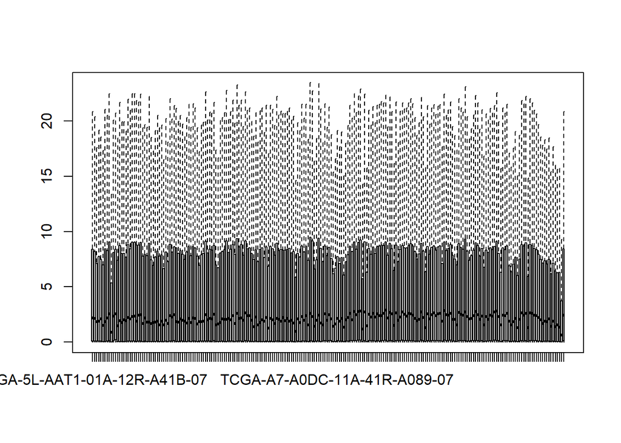

```r
boxplot(dataPrep_Coding, outline = FALSE)
```

Therefore, we will perform a quantile normalization on the samples in an attempt to eliminate batch effects. There are pros and cons to performing this type of normalization. The benefit to normalizing the data includes minimizing batch effects between samples. The downfall for performing this type of normalization is that biological information that is derived from the expression data is obscured or even lost. This would make it difficult to explore molecular biological information such as signal transduction cascades or the regulation of biochemical pathways. In our context, however, normalization is probably not such a bad idea since we are interested in the development of a predictive model that results in final predictions and overarching sample classifications rather than biological meaning within the data sets. The `TCGAbiolinks` package has a pre-optimized function to perform this normalization using the `TCGAanalyze_Normalization()` followed by the `TCGAanalyze_Filtering()` functions. As illustrated in the boxplots below, once normalized, the samples are more comparable between quantiles compared to the pre-normalized data.

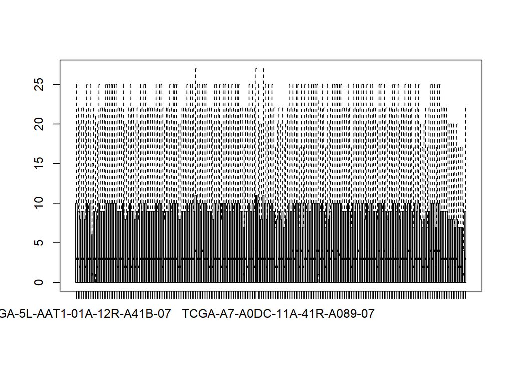

```r
dataNorm_Coding <- TCGAanalyze_Normalization(tabDF = dataPrep_Coding, geneInfo = geneInfoHT, method = "geneLength")
dataFilt_Coding <- TCGAanalyze_Filtering(tabDF = dataPrep_Coding, method = "quantile", qnt.cut =  0.25)
boxplot(dataNorm_Coding, outline = FALSE)
```

Finally, lets perform differential expression analysis to determine which genes are differential expressed between normal and breast cancer tissues in general.

```r
DEGsCoding <- TCGAanalyze_DEA(mat1 = dataFilt_Coding[,dataNormal_Target],
                            mat2 = dataFilt_Coding[,dataPrimary_Target],
                            pipeline="limma",
                            Cond1type = "Normal",
                            Cond2type = "Tumor",
                            fdr.cut = 0.01 ,
                            logFC.cut = 1,
                            method = "glmLRT", ClinicalDF = data.frame())
```

[figure not shown]

```r
head(DEGsCoding)
```

```
##                         logFC   AveExpr         t      P.Value    adj.P.Val
## ENSG00000158966.16  -7.858105  5.773287 -29.16641 2.308285e-78 3.455734e-74
## ENSG00000136158.12 -18.311408 12.924635 -27.09838 9.120470e-73 6.827128e-69
## ENSG00000146648.19 -14.668257 10.434624 -25.66712 9.318086e-69 4.650035e-65
## ENSG00000187824.9   -3.609198  2.810586 -25.08983 4.151070e-67 1.553642e-63
## ENSG00000177098.9   -7.801087  5.628647 -24.98782 8.154717e-67 2.441685e-63
## ENSG00000154065.17  -3.162853  2.357660 -24.56319 1.374615e-65 3.429893e-62
##                           B
## ENSG00000158966.16 167.9304
## ENSG00000136158.12 155.1813
## ENSG00000146648.19 146.0379
## ENSG00000187824.9  142.2754
## ENSG00000177098.9  141.6061
## ENSG00000154065.17 138.8058
```

The introduction up to this point provides you with both the data and minimum amount of information required to build mechanistic models for the predictions of and/or classification of breast cancer tumors.

Your task for this assignment is to take information described in this course and build upon it with your own exploration of this data set leading to the development of a predictive model for the classification of breast cancer samples compared to normal tissue samples. The following subsections provide you with an outline that provides direction to complete the project but the data exploratory portion, how you interpret the results of this exploratory analysis, and how you derive the model is up to you.

#Data Exploration

## 3.2 Gene Correlation

Which genes are associated with continuous data attributes (e.g. days to death, age, ect…)? Do any of these genes represent confounding variables in the data set? Which genes correlate with other genes? to what extent and significance? Which meta data features correlate with each other?

```r
#library(ggplot2)
#genes associated with continuous data attributes - use correlation, cor()
names(colData(data)) #"age_at_diagnosis", "days_to_death"
```

```
##  [1] "barcode"
##  [2] "patient"
##  [3] "sample"
##  [4] "shortLetterCode"
##  [5] "definition"
##  [6] "sample_submitter_id"
##  [7] "sample_type_id"
##  [8] "tumor_descriptor"
##  [9] "sample_id"
## [10] "sample_type"
## [11] "composition"
## [12] "days_to_collection"
## [13] "state"
## [14] "initial_weight"
## [15] "preservation_method"
```

[output cut: 72 more lines]

```r
age <- data$age_at_diagnosis
age <- age/365 #age was in days
ge <- dataPrep_Coding
sample.type <- data$shortLetterCode #TP - primary tumor, NT - normal tissue
days2death <- as.numeric(data$days_to_death)
gene.names <- rowData(data)$gene_name
gene.id <- rowData(data)$gene_id
year.death <- data$year_of_death

##Need to filter out constant genes that may affect data exploration
#Set threshold for standard dev to identify constant genes
threshold <- 0.1  # Adjust this threshold as needed
gene_sd <- apply(ge, 1, sd)# Calculate the standard deviation for each gene
filtered_ge <- ge[which(gene_sd > threshold), ]# Filter out constant genes
#filtered_ge <- t(filtered_ge)

#Calculate the correlation between gene expression (protein_coding) and age
gene_age_cor <- sapply(seq_len(nrow(filtered_ge)), function(i) {
  cor(filtered_ge[i, ], age, use = "complete.obs")
})
#Find genes with significant correlations
alpha <- 0.5
significant.genes.age <- gene.names[gene_age_cor < alpha]
#Sort top 10 most significant genes associated with age.
sort.significant.genes.age <- significant.genes.age[order(abs(gene_age_cor[gene_age_cor < alpha]), decreasing = TRUE)]
top20.significant.genes.age <- sort.significant.genes.age[1:20]
cat("Top 10 most significant genes asspcoated with age:", top20.significant.genes.age)
```

```
## Top 10 most significant genes asspcoated with age: LINC00324 GRM4 PKD2 TMEM138 APLP2 YY1AP1 RASSF1 SUCO CTRL ZSWIM6 ODF2 PNPLA4 DHRS1 CYTIP TRMT10B CACNG7 MRPL9 CETP MCRS1 MRPS23
```

```r
assoc.age.sampletype <- data.frame(Gene = character(0), P_Value = numeric(0))

#Check to see if the genes associated with age confounds with sample type? whats the p-value of these genes?
for (gene_name in top20.significant.genes.age){
  #find index of the current gene in the list of genes
  gene.index <- which(rowData(data)$gene_name == gene_name)
  if (length(gene.index) > 0 ){
    #subset the gene expression data for TP and NT samples
    curr.gene.expr.TP <- filtered_ge[gene.index, data$shortLetterCode == "TP"]
    curr.gene.expr.NT <- filtered_ge[gene.index, data$shortLetterCode == "NT"]
    #perform t-test between TP and NT samples
    age.sampletype.ttest <- t.test(curr.gene.expr.TP, curr.gene.expr.NT)
    #store the results in the associations dataframe
    assoc.age.sampletype <- rbind(assoc.age.sampletype, data.frame(Gene=gene_name, P_Value = age.sampletype.ttest$p.value))
  }
}
#Adjust p-values?
adj.assoc.agesampletype.pval <- p.adjust(assoc.age.sampletype$P_Value, method = "BH")
assoc.age.sampletype$Adj_P_Value <- adj.assoc.agesampletype.pval
#sort the dataframe in ascending order (most significant first)
sort.assoc.age.sampletype <- assoc.age.sampletype[order(assoc.age.sampletype$Adj_P_Value),]
print(sort.assoc.age.sampletype) #The genes found from age confounds with certain sample types of BRCA
```

```
##         Gene      P_Value  Adj_P_Value
## 15   TRMT10B 1.302215e-46 2.604431e-45
## 20    MRPS23 6.433717e-34 6.433717e-33
## 11      ODF2 2.238897e-23 1.492598e-22
## 7     RASSF1 1.185906e-14 5.929530e-14
## 3       PKD2 4.238984e-13 1.695594e-12
## 10    ZSWIM6 3.151226e-12 1.050409e-11
## 8       SUCO 1.135833e-11 3.245237e-11
## 13     DHRS1 3.541975e-10 8.854937e-10
## 19     MCRS1 5.013246e-10 1.114055e-09
## 12    PNPLA4 8.465523e-10 1.693105e-09
## 6     YY1AP1 4.415980e-08 8.029055e-08
## 1  LINC00324 5.336198e-08 8.893663e-08
## 2       GRM4 2.666087e-06 4.101673e-06
## 14     CYTIP 6.492429e-06 9.274898e-06
## 16    CACNG7 4.343375e-03 5.791166e-03
## 18      CETP 8.534935e-03 1.066867e-02
## 9       CTRL 6.315453e-02 7.429944e-02
## 4    TMEM138 6.709158e-02 7.454620e-02
## 5      APLP2 1.682172e-01 1.770707e-01
## 17     MRPL9 4.211021e-01 4.211021e-01
```

```r
#How does the top 20 genes we found form age correlate with other genes in filtered_ge?
#initialize empty list to store correlation matrices
correlation_matrices <- list()
#Check which genes are correlated with other genes in this list
for (gene in sort.assoc.age.sampletype$Gene){
  genepair.index <- which(rowData(data)$gene_name == gene)
  #subset the gene expression data
  genepair.expr <- filtered_ge[genepair.index,]
  #calculate the correlations between the current gene and all other genes
  genepair.cor <- cor(t(filtered_ge), genepair.expr, method ="pearson")
  #store the correlation matrix in a list
  correlation_matrices[[gene]] <- genepair.cor
}

#To determine the extent (strength of correlation) and significance (p-value) of correlations between these genes, we will extract correlation coefficients and p-values. Highly correlated genes may be functionally related or co-regulated.

#initialize empty correlation matrix
gene_correlation_matrix <- matrix(NA, nrow = ncol(filtered_ge), ncol = ncol(filtered_ge))
#initialize vector to store gene names
gene_names <- character(ncol(filtered_ge))
#loop through each pair of genes and calculate correlation
for (i in 1:(ncol(filtered_ge)-1)){
  for(j in (i+1):ncol(filtered_ge)){
    gene1  <- filtered_ge[,i]
    gene2 <- filtered_ge[,j]
    #exclude missing values (NAs) when calculating correlation
    valid_rows <- complete.cases(gene1, gene2)
    if(sum(valid_rows)>=2){
      correlation_coefficient <- cor(gene1[valid_rows], gene2[valid_rows], method = "pearson")
      gene_correlation_matrix[i,j] <- correlation_coefficient
      gene_correlation_matrix[j, i] <- correlation_coefficient
      #Assign gene names to corresponding indices
      gene_names[i] <- gene.names[i]
      gene_names[j] <- gene.names[j]
    }
  }
}
#set diagonal elements to 1 (genes correlated with themselves)
diag(gene_correlation_matrix) <- 1
#set row and column names
rownames(gene_correlation_matrix) <- gene_names
colnames(gene_correlation_matrix) <- gene_names
#gene_correlation_matrix contains correlation coefficients between genes - use this to identify highly correlated genes and assess the extent and significance of these correlations
#set correlation threshold for identifying highly correlated genes
correlation_threshold <- 0.8
#identify highly correlated gene pairs
highly_correlated_genes <- list()
# Loop through all pairs of genes
for (i in 1:(ncol(filtered_ge) - 1)) {
  for (j in seq(i + 1, ncol(filtered_ge))) {
    correlation_coefficient <- gene_correlation_matrix[i, j]

    if (abs(correlation_coefficient) >= correlation_threshold) {
      # Calculate the p-value of the correlation using the gene_correlation_matrix
      p_value <- cor.test(gene_correlation_matrix[i, ], gene_correlation_matrix[j, ], method = "pearson")$p.value

      # Store information about highly correlated genes
      gene_pair <- c(rownames(gene_correlation_matrix)[i], rownames(gene_correlation_matrix)[j])
      correlation_strength <- correlation_coefficient
      significance <- format(p_value, nsmall = 5)

      highly_correlated_genes[[paste(i, j, sep = "-")]] <- list(
        GenePair = gene_pair,
        CorrelationStrength = correlation_strength,
        Significance = significance
      )
    }
  }
}
# Sort the highly correlated genes by both strength and significance
sorted_gene_indices <- order(
  sapply(highly_correlated_genes, function(x) abs(x$CorrelationStrength)),
  decreasing = TRUE
)

# Print the top 20 highly correlated genes. These gene pairs have high positive correlation and are statistically significant. This suggests that the expression levels of these genes are closely related, and changes in one gene's expression may be associated with changes in the other's expression.
cat("Top 20 Highly Correlated Genes:\n")
```

```
## Top 20 Highly Correlated Genes:
```

```r
for (i in 1:min(20, length(sorted_gene_indices))) {
  gene_info <- highly_correlated_genes[[sorted_gene_indices[i]]]
  cat("Gene Pair:", gene_info$GenePair[1], "and", gene_info$GenePair[2], "\n")
  cat("Correlation Strength:", gene_info$CorrelationStrength, "\n")
  cat("Significance (p-value):", gene_info$Significance, "\n\n")
}
```

```
## Gene Pair: CYTH3 and ST3GAL1
## Correlation Strength: 0.9959503
## Significance (p-value): 2.330783e-312
##
## Gene Pair: PAFAH1B1 and CRAMP1
## Correlation Strength: 0.995416
## Significance (p-value): 8.610557e-293
##
## Gene Pair: MATK and CRAMP1
## Correlation Strength: 0.9948852
## Significance (p-value): 2.301303e-305
##
## Gene Pair: CEACAM7 and CRAMP1
## Correlation Strength: 0.9948267
## Significance (p-value): 1.813536e-301
##
## Gene Pair: MYLIP and ST3GAL1
## Correlation Strength: 0.9943888
## Significance (p-value): 8.966716e-294
##
## Gene Pair: CCDC124 and JARID2
## Correlation Strength: 0.9941999
## Significance (p-value): 3.606078e-305
##
## Gene Pair: CRY1 and NFIX
## Correlation Strength: 0.9938435
## Significance (p-value): 5.056672e-310
##
## Gene Pair: JARID2 and ST3GAL1
## Correlation Strength: 0.9937883
## Significance (p-value): 2.384547e-274
##
## Gene Pair: KRT33A and MATK
## Correlation Strength: 0.9937617
## Significance (p-value): 1.016659e-306
##
## Gene Pair: CCDC124 and ST3GAL1
## Correlation Strength: 0.9936957
## Significance (p-value): 3.507414e-282
##
```

[output cut: 24 more lines]

```
## Gene Pair: SLC13A2 and CRAMP1
## Correlation Strength: 0.9923528
## Significance (p-value): 2.387932e-235
##
## Gene Pair: PAFAH1B1 and FMO3
## Correlation Strength: 0.9922966
## Significance (p-value): 9.436643e-271
##
## Gene Pair: CRAMP1 and FMO3
## Correlation Strength: 0.9921746
## Significance (p-value): 5.130392e-239
##
## Gene Pair: JARID2 and CYTH3
## Correlation Strength: 0.992067
## Significance (p-value): 1.264307e-260
```

```r
#Which metadata features correlate with each other?
#Does age correlate with sample type?
#filter "TP" and "NP" sample time
data_TP <- data[data$shortLetterCode == "TP"]
data_NT <- data[data$shortLetterCode == "NT"]
# Create contingency tables for age and sample type separately
contingency_table_TP <- table(data_TP$age_at_diagnosis, data_TP$shortLetterCode)
contingency_table_NT <- table(data_NT$age_at_diagnosis, data_NT$shortLetterCode)
# Perform Fisher's exact test for "TP" sample type
fisher_exact_TP <- fisher.test(contingency_table_TP)
fisher_exact_NT <- fisher.test(contingency_table_NT)
chi_square_TP <- chisq.test(contingency_table_TP)
chi_square_NT <- chisq.test(contingency_table_NT)
#The p-value for TP and NT are high for fisher and chi square so sample types may not be correlated with age. but the genes found in age do confound with sample type.

age.year.death.cor <- cor(age,days2death, method="pearson", use="complete.obs")
print(age.year.death.cor)
```

```
## [1] -0.1558792
```

## 3.3 Exploration of variance in the data

Which genes explain the greatest variance in the data? Which ones explain the least? Please explain why exploring the variance in the data is important for model building and how you would determine which genes to include in the model.

```r
#Identify genes with the greatest variance in the data (filtered_ge)
gene.variances <- apply(filtered_ge, 1, sd)
#sort genes by highest variance
sorted.gene.variances.high <- gene.names[order(gene.variances,decreasing=TRUE)]
#sort genes by lowest variance
sorted.gene.variances.low <- gene.names[order(gene.variances, decreasing=FALSE)]
# Print genes with highest variance and their variances
cat("Genes with Highest Variance:\n")
```

```
## Genes with Highest Variance:
```

```r
for (gene_name in sorted.gene.variances.high[1:20]) {  # Adjust the number of genes you want to print
  variance <- gene.variances[which(gene.names == gene_name)]
  cat("Gene:", gene_name, "\t Variance:", variance, "\n")
}
```

```
## Gene: LINC00471   Variance: 4514.904
## Gene: PHLDA2      Variance: 4342.028
## Gene: OR52N4      Variance: 3947.077
## Gene: GLRX5P1     Variance: 3898.497
## Gene: GPR88   Variance: 3512.197
## Gene: HSP90AA6P   Variance: 3432.638
## Gene: AC004832.1      Variance: 3259.15
## Gene: TMEM132C    Variance: 3131.979
## Gene: EPG5    Variance: 2923.23
## Gene: AL596028.1      Variance: 2793.519
## Gene: AK6     Variance: 1915.962
## Gene: RBP5    Variance: 1829.995
## Gene: SLC26A11    Variance: 1657.783
## Gene: EIPR1   Variance: 1525.922
## Gene: JRKL    Variance: 1414.398
## Gene: MORC3   Variance: 1359.313
## Gene: MTERF4      Variance: 1354.347
## Gene: TMEM132E    Variance: 1320.249
## Gene: C12orf54    Variance: 1269.869
## Gene: DEUP1   Variance: 1036.715
```

```r
# Print genes with lowest variance and their variances
cat("\nGenes with Lowest Variance:\n")
```

```
##
## Genes with Lowest Variance:
```

```r
for (gene_name in sorted.gene.variances.low[1:20]) {  # Adjust the number of genes you want to print
  variance <- gene.variances[which(gene.names == gene_name)]
  cat("Gene:", gene_name, "\t Variance:", variance, "\n")
}
```

```
## Gene: TMED7   Variance: 0.1000258
## Gene: CD244   Variance: 0.1000295
## Gene: PPP1CC      Variance: 0.1000311
## Gene: TOR3A   Variance: 0.1000506
## Gene: LCA5    Variance: 0.1000691
## Gene: EFCAB6      Variance: 0.100099
## Gene: OR7E14P     Variance: 0.1001321
## Gene: PCBP1-AS1   Variance: 0.1001338
## Gene: PIK3R2      Variance: 0.1001832
## Gene: SPATA12     Variance: 0.1003598
## Gene: MINPP1      Variance: 0.1005068
## Gene: GALNT5      Variance: 0.1005375
## Gene: PPM1E   Variance: 0.1005391
## Gene: KRT5    Variance: 0.1007608
## Gene: MCRS1   Variance: 0.1007721
## Gene: ATP8A1      Variance: 0.1008132
## Gene: SEPTIN5     Variance: 0.1008495
## Gene: ANTKMT      Variance: 0.1008754
## Gene: FRMD8   Variance: 0.1008851
## Gene: GGT2    Variance: 0.1009228
```

Exploring variance in data is important for model building so owe can identify which features have significant variation in their expression levels. Genes with low variance may not provide meaningful information for modeling and may be subjected to noise. High variance features can lead to overfitting in machine learning models. However, selecting high variance can give us insight on any potential biologically relevance and could be the outcome of interest.

## 3.4 Principle Component Analysis

Perform a PCA analysis on the data and explain is there are any data attributes that are separated into different clusters by the PCA analysis. Please explain why exploring this is important for model building.

```r
library(rgl);library(scatterplot3d)
#convert the gene ids from filtered_ge to gene names.
filtered_ge_gene_ids <- rownames(filtered_ge)
filtered_ge_gene_names <- rowData(data)$gene_name[match(filtered_ge_gene_ids, rowData(data)$gene_id)]
rownames(filtered_ge) <- filtered_ge_gene_names
#perform PCA analysis:
#create a new 3D plot window
open3d()
```

```
## wgl
##   1
```

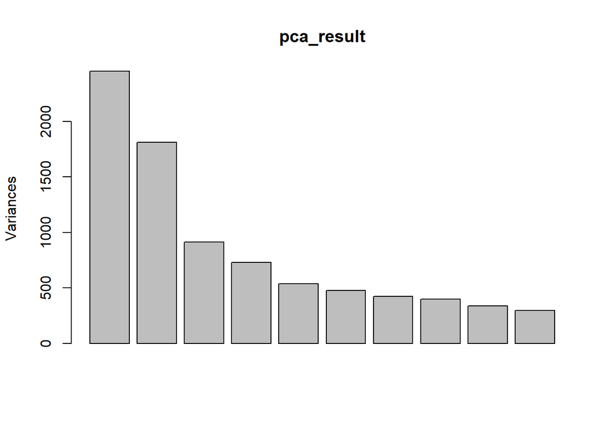

```r
colors <- rainbow(length(age))
pca_result <- prcomp(t(filtered_ge), scale = TRUE)
plot(pca_result)
```

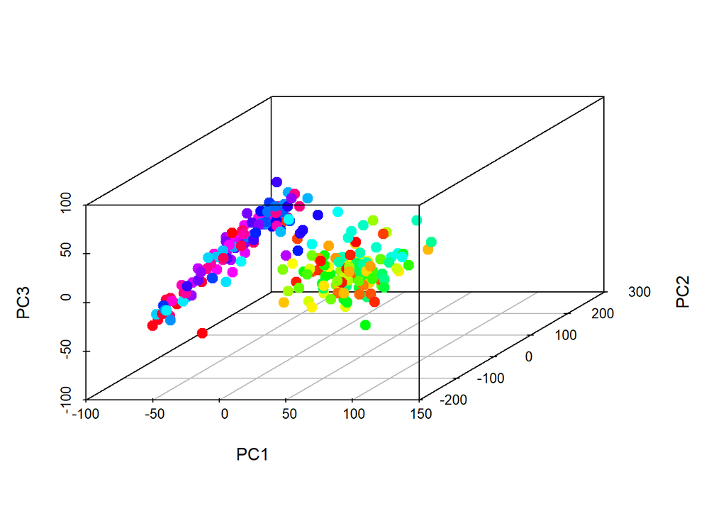

```r
sc3 = scatterplot3d(pca_result$x[,1:3], pch=20, highlight.3d = FALSE, cex.symbol=2, color=colors)
```

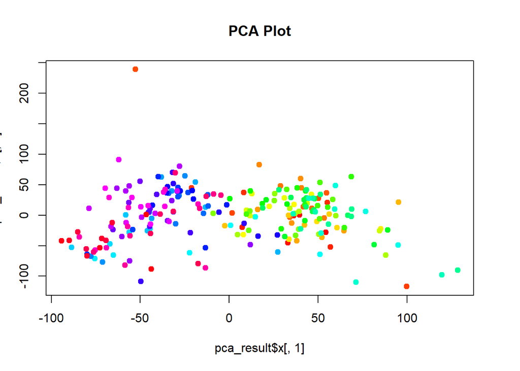

```r
sc3d.coords <- sc3$xyz.convert(pca_result$x[,1:3])
#text(sc3d.coords$x,sc3d.coords$y, labels = rownames(filtered_ge),cex=0.8, pos=4)
# Plot the principal components
#plot PC1-PC2
plot(pca_result$x[, 1], pca_result$x[, 2], main = "PCA Plot", col = colors, pch = 19)
```

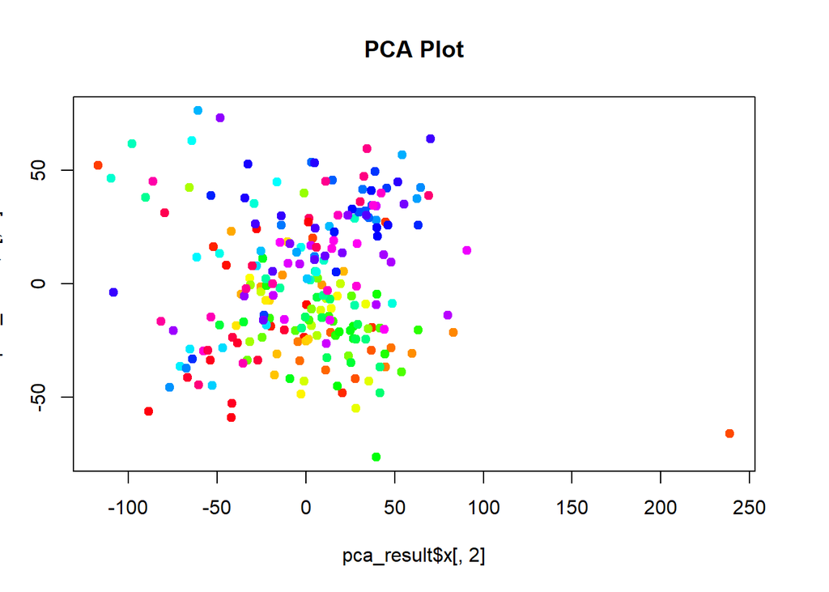

```r
#plot PC2-PC3
plot(pca_result$x[,2], pca_result$x[,3], main="PCA Plot", col = colors, pch = 19)
```

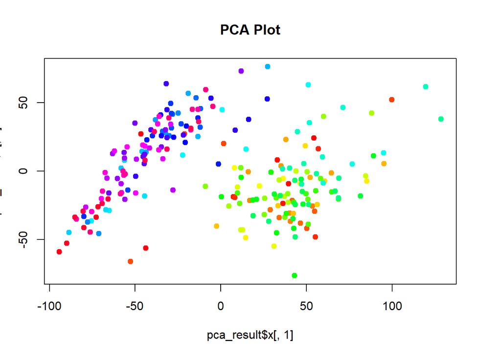

```r
#plot PC1-PC3
plot(pca_result$x[,1], pca_result$x[,3], main="PCA Plot", col= colors, pch=19)
```

```r
#PC1-Pc2-PC3 projection
plot3d(pca_result$x[,1], pca_result$x[,2], pca_result$x[,3], col=colors, type = "s", size = 2, xlab="PC1", ylab="PC2", zlab="PC3")
legend3d("topright", legend = unique(rownames(filtered_ge)), pch = 16, col = colors, cex=0.7)

# Save the 3D plot as an interactive HTML widget
htmlwidgets::saveWidget(widget = rglwidget(), file = "3D_PCA_Plot.html")

# Embed the 3D plot in the R Markdown output
htmltools::includeHTML("3D_PCA_Plot.html")
```

[interactive chart not shown]

Across these graphs, we can see 2 major clusters. The dark blues, purple, and pinks are clustered together while light greens and yellows are clustered together. Earlier I was looking at the significance in genes and sample types. We could be seeing clusters of genes that are similar by sample types.

# 4 Model Development

Separate into testing and training data sets.

Build a logistic regression/linear regression, random forest, SVM, neural network models on the prediction of which people have breast cancer. When building this model, Please consider what parameters can be tuned in each model and describe how you would decide how to set these parameters.

```r
library(Biobase); library(tree);library(e1071);library(neuralnet)
#Functions
#predict.SVM function
# Define the predict.SVM function
predict.SVM = list(
  model = NULL,
  train = function(f, data, ...) {
    # Train your SVM model and store it in the predictor
    predict.SVM$model <<- svm(f, data, ...)
  },
  predict = function(newdata = NULL) {
    # Check that we have data and that the model was trained
    if (is.null(newdata) || is.null(predict.SVM$model)) {
      stop("Model not trained or missing data for prediction.")
    }

    # Predict using the SVM model
    predictions <- predict(predict.SVM$model, newdata)

    # Convert factor predictions into a numeric vector
    numeric_predictions <- as.numeric(as.character(predictions))

    return(numeric_predictions)
  }
)

do.check=function(data,model) {
if ( is.null(data) ) { stop("New data must be specified") }
if ( is.null(model) ) {
stop("The model has not been trained yet!")
}
}

predictor.LR = list(
model = NULL,
train = function(f,data,...) {

predictor.LR$model <<- glm(f, data,
family="binomial",na.action="na.exclude", maxit=1000, ...)
},
predict=function(newdata=NULL) {
# check that we got data and that the model was already trained:
do.check(newdata,predictor.LR$model)

as.numeric(
predict(predictor.LR$model,newdata,type="response") > 0.5
)
}
)

predictor.NN = list(
model = NULL,
train = function(f,data,...) {
# note that we are using our fixed implementation of the neural net:
predictor.NN$model <<- neuralnet.fx(f, data, ...)
},
predict=function(newdata=NULL) {
do.check(newdata,predictor.NN$model)

as.numeric(
compute(predictor.NN$model,newdata)$net.result > 0.5
)
}
)

#Cross-validate function
cross.validate <- function(predictor, formula, data = NULL, method = "random", N = 1000, n.out = 5, ...) {
  if (is.null(data)) {
    stop("data must be specified")
  }

  f.str <- deparse(formula)
  dependent.name <- sub("\\s*~.*", "", f.str)
  if (!dependent.name %in% names(data)) {
    dependent.data <- get(dependent.name, envir = environment(formula))
    data <- cbind(dependent.data, data)
    names(data)[1] <- dependent.name
  } else {
    ind <- match(dependent.name, names(data))
    data <- cbind(data[, ind, drop = FALSE], data[, -ind, drop = FALSE])
  }

  truth <- data[, dependent.name]
  prediction <- numeric()

  # Split the data into training and test sets
  for (i in 1:N) {
    #check if youre in endless loop
    #cat("Iteration:", i, "\n")
    leave.out <- sample(nrow(data), size = n.out)
    training.data <- data[-leave.out, , drop = FALSE]
    test.data <- data[leave.out, , drop = FALSE]

    # Train the SVM model within each fold
    predictor$train(as.formula(paste(dependent.name, "~ .")), training.data, ...)

    # Make predictions on test data using the trained SVM model
    pred <- predictor$predict(test.data[, -1, drop = FALSE])
    truth[(length(truth) + 1):(length(truth) + n.out)] <- test.data[, dependent.name]
    prediction <- c(prediction, pred)
  }

  list(truth = truth, prediction = prediction)
}

assess.prediction=function(truth,predicted,print.results=FALSE) {
predicted = predicted[ ! is.na(truth) ]
truth = truth[ ! is.na(truth) ]
truth = truth[ ! is.na(predicted) ]
predicted = predicted[ ! is.na(predicted) ]
result = list()
result$accuracy = sum(truth==predicted)*100/length(truth)
if ( print.results ) {
cat("Total cases that are not NA: ",length(truth),"\n",sep="")
cat("Correct predictions (accuracy): ",sum(truth==predicted),
"(",signif(result$accuracy,3),"%)\n",sep="")
}
TP = sum(truth==1 & predicted==1)
TN = sum(truth==0 & predicted==0)
FP = sum(truth==0 & predicted==1)
FN = sum(truth==1 & predicted==0)
P = TP+FN
N = FP+TN # total number of negatives
result$TPR = 100*TP/P
result$TNR = 100*TN/N
result$PPV = 100*TP/(TP+FP)
result$FDR = 100*FP/(TP+FP)
result$FPR = 100*FP/N
if ( print.results ) {
cat("TPR (sensitivity)=TP/P: ", signif(result$TPR,3),"%\n",sep="")
cat("TNR (specificity)=TN/N: ", signif(result$TNR,3),"%\n",sep="")
cat("PPV (precision)=TP/(TP+FP): ", signif(result$PPV,3),"%\n",sep="")
cat("FDR (false discovery)=1-PPV: ", signif(result$FDR,3),"%\n",sep="")
cat("FPR =FP/N=1-TNR: ", signif(result$FPR,3),"%\n",sep="")
}
if ( print.results ) { invisible(result) }
else { result }
}


set.seed(123)

#response variable
data$has_cancer <-ifelse(data$shortLetterCode == "TP", 1, 0)
has_cancer <- as.factor(data$has_cancer)
filtered_ge <- as.data.frame(filtered_ge)
#pvalues of genes
tt.pvals=apply(filtered_ge,1,function(x) t.test( x ~ has_cancer )$p.value )
df = as.data.frame(t(filtered_ge[order(tt.pvals),]))
top_gene_indices <- order(tt.pvals)[1:20]
top_gene_data <- t(filtered_ge[top_gene_indices,])
data_for_model <- data.frame(top_gene_data, has_cancer)
# Cross-validate the SVM model top 20 genes
# Initialize matrices for fit and prediction metrics
fit.metrics = matrix(ncol = 20, nrow = 3)
pred.metrics = matrix(ncol = 20, nrow = 3)
row.names(fit.metrics) = c("ACC", "TPR", "TNR")
row.names(pred.metrics) = c("ACC", "TPR", "TNR")

# Loop through different numbers of variables (K = 1 to 20)
for (n.var in 1:20) {
  # Train your SVM model using your predict.SVM wrapper
  predict.SVM$train(has_cancer ~ . , df[, 1:n.var, drop = FALSE])

  # Calculate and store fit metrics for each n.var
  metrics_fit = assess.prediction(has_cancer, predict.SVM$predict(df[, 1:n.var, drop = FALSE]))
  fit.metrics[, n.var] = c(metrics_fit$accuracy, metrics_fit$TPR, metrics_fit$TNR)

  # Cross-validate using your professor's cross.validate function and store prediction metrics
  c.val = cross.validate(predictor = predict.SVM, formula = has_cancer ~ . , data = df[, 1:n.var, drop = FALSE])
  metrics_pred = assess.prediction(c.val$truth, c.val$prediction)
  pred.metrics[, n.var] = c(metrics_pred$accuracy, metrics_pred$TPR, metrics_pred$TNR)
}

#Assess prediction accuracy of predict SVM.
assess.prediction(c.val$truth, c.val$prediction)
```

```
## $accuracy
## [1] 50.22
##
## $TPR
## [1] 50.76741
##
## $TNR
## [1] 49.65433
##
## $PPV
## [1] 51.02848
##
## $FDR
## [1] 48.97152
##
## $FPR
## [1] 50.34567
```

```r
#Linear Regression predictor.LR
cv.LR=cross.validate(predictor.LR, has_cancer ~ ., data=data_for_model)
assess.prediction(cv.LR$truth, cv.LR$prediction)
```

```
## $accuracy
## [1] 49.94
##
## $TPR
## [1] 50.36203
##
## $TNR
## [1] 49.52267
##
## $PPV
## [1] 49.66283
##
## $FDR
## [1] 50.33717
##
## $FPR
## [1] 50.47733
```

```r
#predictor.T (tree model)
predictor.T = list(
model = NULL,
train = function(f,data,...) {
predictor.T$model <<- tree(f, data, ...)
},
predict=function(newdata=NULL) {
do.check(newdata,predictor.T$model)
# implementation of predict() for decision tree models
# is “smart” enough to returns a *factor*; this will cause
# problems for our cross.validate() function that expects the
# predictions to be a simple numeric vector, so we convert here:
as.numeric(as.vector(
predict(predictor.T$model,newdata,type="class")
))
}
)
#tree model
tree_model <- tree(has_cancer ~ ., data= data_for_model)
cv.t <- cross.validate(predictor.T, has_cancer~.,data=data_for_model)
assess.prediction(cv.t$truth, cv.t$prediction)
```

```
## $accuracy
## [1] 49.74
##
## $TPR
## [1] 49.86139
##
## $TNR
## [1] 49.61616
##
## $PPV
## [1] 50.23943
##
## $FDR
## [1] 49.76057
##
## $FPR
## [1] 50.38384
```

## 4.1 Model Testing

Compare the performance of each model and describe why you think one model performed better than the others.